```python
from IPython.display import display
from IPython.display import HTML
import IPython.core.display as di # Example: di.display_html('<h3>%s:</h3>' % str, raw=True)

# This line will hide code by default when the notebook is exported as HTML
di.display_html('<script>jQuery(function() {if (jQuery("body.notebook_app").length == 0) { jQuery(".input_area").toggle(); jQuery(".prompt").toggle();}});</script>', raw=True)

# This line will add a button to toggle visibility of code blocks, for use with the HTML export version
di.display_html('''<button onclick="jQuery('.input_area').toggle(); jQuery('.prompt').toggle();">Toggle code</button>''', raw=True)
```

```python
import numpy as np, pandas as pd, matplotlib.pyplot as plt
plt.style.use('bmh')
import math
import matplotlib
matplotlib.rcParams.update({'font.size': 12, 'font.family': 'sans-serif'})
pd.options.display.float_format = '{:.3f}'.format
```

# The Journey of a developer

| [*Home*](https://antonio-catalano.github.io/) | [*About*](https://antonio-catalano.github.io/about.html) | [*Archive*](https://antonio-catalano.github.io/Archive.html) |  |
| --- | --- | --- | --- |

# Some considerations about the Case Fatality Ratio of Covid-19

This notebook study was born by the interest aroused by reading the following article about the **Case Fatality Ratio** (**CFR**) of Covid19: [Mark Bevand Blog](http://blog.zorinaq.com/case-fatality-ratio-ncov/)  
I highly suggest to read it before to dive into this notebook.

Let's focus on two ways to estimate the *case fatality ratio* (**CFR**) :

*Naive Estimator = Current Deaths / Current Cases*  
*Resolved Estimator = Current Deaths / (Current Deaths + Current Recovered)*

The aim of this notebook is not to compute the unbiased estimate of the **CFR**, because in order to do that we have to model other factors and make other assumptions (check out the final part of the [Mark Bevand Blog](http://blog.zorinaq.com/case-fatality-ratio-ncov/)).  
The aim is to understand if and why we should prefer the *Naive Estimator* or the *Resolved Estimator* in order to infer the severity of the epidemic.

We import the Covid-19 data of the most infected Countries at **28th February 2020**.

```python
data = pd.read_excel('D:\Covid19\data_28feb.xlsx').set_index('Country')
```

In order to compute a weighted average we calculate the countries weighs by adding a new column.

```python
data['weigh'] = data['Cases'] / data['Cases'].sum(axis = 0)
data
```

| Country | Cases | Deaths | Recovered | Critical | weigh |
| --- | --- | --- | --- | --- | --- |
| China | 78832 | 2788 | 36456 | 7952 | 0.941 |
| S.Korea | 2337 | 16 | 24 | 7 | 0.028 |
| Italy | 888 | 21 | 46 | 64 | 0.011 |
| Diamond Princess | 705 | 6 | 10 | 34 | 0.008 |
| Iran | 388 | 34 | 73 | 0 | 0.005 |
| Japan | 226 | 5 | 32 | 13 | 0.003 |
| Singapore | 96 | 0 | 69 | 8 | 0.001 |
| Hong Kong | 93 | 2 | 18 | 6 | 0.001 |
| Usa | 62 | 0 | 6 | 1 | 0.001 |
| Germany | 60 | 0 | 16 | 2 | 0.001 |
| France | 57 | 2 | 11 | 1 | 0.001 |

Let's calculate the two current estimates:

```python
naive_est = (data['Deaths'] / data['Cases'] * data['weigh']).sum()
resolved_est = (data['Deaths'] / (data['Deaths']+data['Recovered']) * data['weigh']).sum()
```

```python
cfr = pd.DataFrame(np.array([naive_est, resolved_est])*100, columns = ['CFR'], \
                   index = ['Naive Estimator (%)', 'Resolved Estimator (%)'])
cfr
```

|  | CFR |
| --- | --- |
| Naive Estimator (%) | 3.432 |
| Resolved Estimator (%) | 8.657 |

We know that at the end of the pandemic the two metrics must coincide.  
But in the middle of the pandemic they would tipically differ.

The problem is: which of the two estimators is more biased during the pandemic?

It seems that the *Naive Estimator* underestimates the real value, because the pandemic is still ongoing.  
On the contrary the *Resolved Estimator* seems to overestimate the real value.

We are going to show that if we use a logistic growth model for the epidemic (slow increasing initially, rapid exponentially increasing after a while and negative 2nd derivative after the temporal mid point of the pandemic (when quarantines start working) ), the bias of the two measures **doesn't depend** on the *death probability* , but only on the *death lag* (the average number of days between diagnosis and death) and the *recovery lag* (the average number of days between diagnosis and recovery).

We are going to highlight that if those lags coincide hence the *Resolved Estimator* computes a **perfect** estimate of the real value, at any day.

Let's define a new variable, the *Recovery multiple*.  
*Recovery multiple* = *Recovery Lag* / *Death Lag*

This notebook will highlight the following results:

If the *Recovery Multiple* is $< 1.5$ the *Naive CFR* bias is higher than the *Resolved Estimator* bias.  
In other words: *Naive CFR* underestimates too much the real value compared to how *Resolved Estimator* overestimates.

If the *Recovery Multiple* is $\approx 1.5$ they will have a similar bias (*Naive CFR* would underestimate in the same manner as *Resolved CFR* would overestimate).

If the *Recovery Multiple* is $>= 2$ the *Naive CFR* bias is smaller than the *Resolved Estimator* bias.  
In other words: *Resolved Estimator* overestimates too much the real CFR compared to how *Naive Estimator* underestimates.

In our simulation we assume that pandemic will last 200 days.  
The accuracy of this assumption is not fundamental for our aim.  
We use a growth rate of the logistic function $k = 0.08$, as the author of original article did.

Let's start by showing that, **regardless the death probability $p$**, if the death lag is equal to the recovery lag, the *Naive CFR* ratio always underestimates the true CFR, while the *Resolved CFR* is a **perfect estimator**.

```python
def sim(p = 0.1, time_to_death = 21, time_to_heal = 21, k = 0.08):
    population = 100_000
    days = 200
    death_prob = p
    time_to_death = time_to_death
    time_to_heal = time_to_heal
    hist = [0] # no cases before the storm
    deaths = recovs = naive_cfr = resolved_cfr = 0
    df = pd.DataFrame(index = pd.date_range(start = '15-12-2020', periods = days), \
                      columns = 'day,cases,deaths,recoveries,Naive CFR (%),Resolved CFR (%)'.split(','))

    for d in range(1, days):
        cases = round(population / (1 + math.e**(-k*(d - days/2))))
        hist.append(cases)

        if d >= time_to_death + 1:
            new_cases_lagged = hist[d - time_to_death] - hist[d - time_to_death - 1]
            new_deaths_lagged = (new_cases_lagged) * death_prob
            deaths += new_deaths_lagged

        if d >= time_to_heal + 1:
            new_cases_lagged = hist[d - time_to_heal] - hist[d - time_to_heal - 1]
            new_recovs_lagged = (new_cases_lagged) * (1 - death_prob)
            recovs += new_recovs_lagged

        if d > max(time_to_death, time_to_heal):
            if cases:
                naive_cfr = 100 * deaths / cases
            if deaths + recovs:
                resolved_cfr = 100 * deaths / (deaths + recovs)

        df.iloc[d-1] = [d, cases, deaths, recovs, naive_cfr, resolved_cfr]
    return df
```

```python
%%javascript
IPython.OutputArea.prototype._should_scroll = function(lines) {
    return false;
}
```

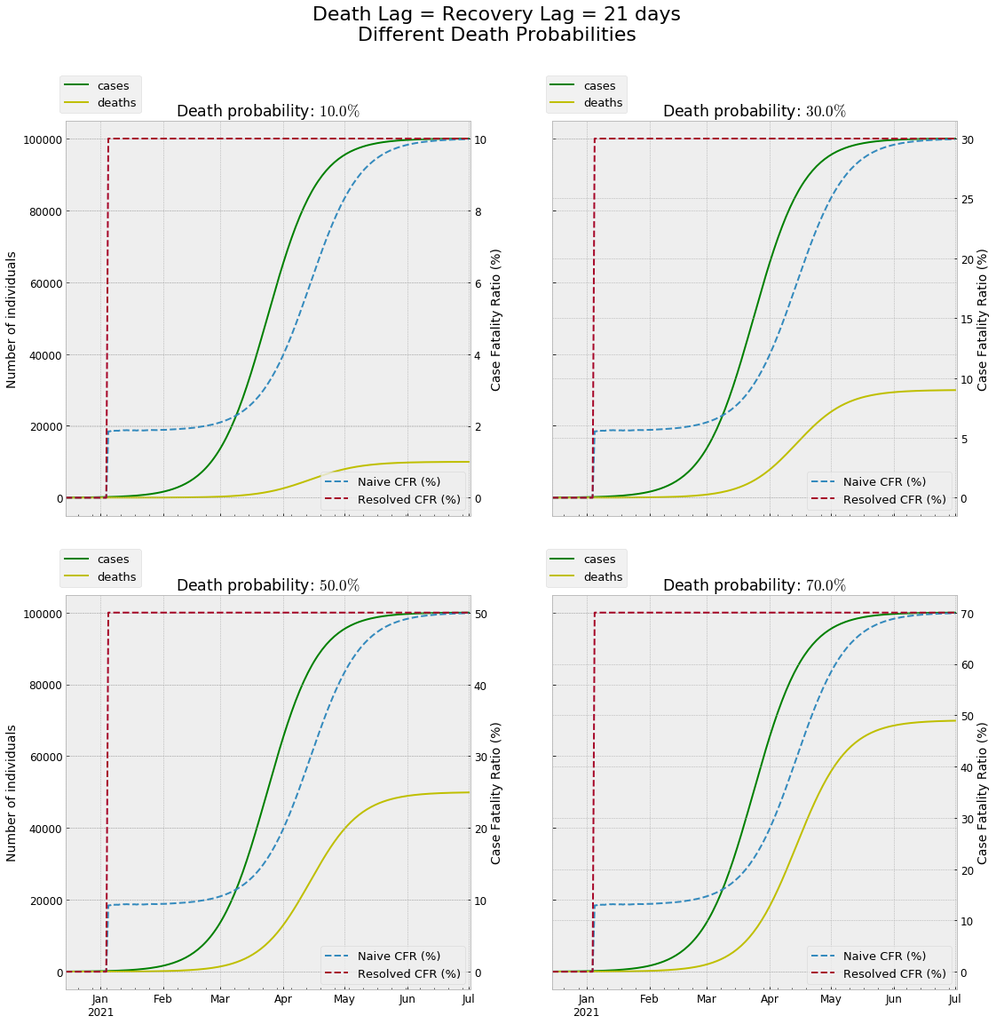

```python
fig, ax = plt.subplots(2,2, sharex=True, sharey=True, figsize = (18,18))
fig.suptitle(f'Death Lag = Recovery Lag = 21 days\nDifferent Death Probabilities', fontsize = 22)
death_probs = [0.1, 0.3, 0.5, 0.7]
j = 0
for i in range(0,2):
    for k in range(0,2):
        df = sim(p = death_probs[j])
        ax1 = ax[i,k].twinx()
        df[['Naive CFR (%)', 'Resolved CFR (%)']].plot(linestyle = '--', ax = ax1);
        df[['cases','deaths']].plot(ax = ax[i,k], label = ['Cum. Cases', 'Cum. Deaths'], color = ['g','y']);
        ax[i,k].set_title(f'Death probability: ${death_probs[j]*100}\%$')
        ax[i,k].set_ylabel('Number of individuals', fontsize = 14)
        ax1.set_ylabel('Case Fatality Ratio (%)', fontsize = 14)
        ax[i,k].legend(bbox_to_anchor=(0, 0.93, 0.2, 0.2), fontsize = 13)
        ax1.legend(loc = 4, fontsize = 13);
        j += 1
```

Now instead we want to hypothesize that:  
*death lag $\neq$ recovery lag* , and we set the *death probability* $p = 0.1$.  
Hence the real $CFR = 0.1 $. We can choose every $p \in (0,1) $. The choice of $p$ doesn't alter the results.

In this case the two **CFR** metrics will differ.  
We are going to use 6 combinations of lags, where the first element of each tuple is the *death lag* and the second element of the same tuple is the *recovery lag*.  
We have realistically chosen a *recovery lag* always higher than *death lag*.

```python
from itertools import product
```

```python
lag_death = [10,16,21] # list of days before death
lag_recover = [15,20,30] # list of days before recovery
```

```python
combos = product(lag_death, lag_recover)

# we want realistically consider only combos in which recovery takes longer than death
combos = [combo for combo in list(combos) if combo[0] < combo[1] ]
combos
```

```
[(10, 15), (10, 20), (10, 30), (16, 20), (16, 30), (21, 30)]
```

By fixing different lags for death and recovery, with *recovery lag $>$ death lag* , we find that:

1) If the ratio *recovery lag / death lag* $<$ 1.5 the *Naive CFR* underestimation bias is larger than the *Resolved CFR* overestimation bias. (Fig. (2x2) )

1) If the ratio *recovery lag / death lag* $\approx$ 1.5 the *Naive CFR* underestimation has the same bias compared to the *Resolved CFR* overestimation. (Fig. (1x1))

2) If the ratio *recovery lag / death lag* $>=$ 2 the *Naive CFR* underestimation bias is minor than the *Resolved CFR* overestimation bias. (Fig. (2x1) and (1x2))

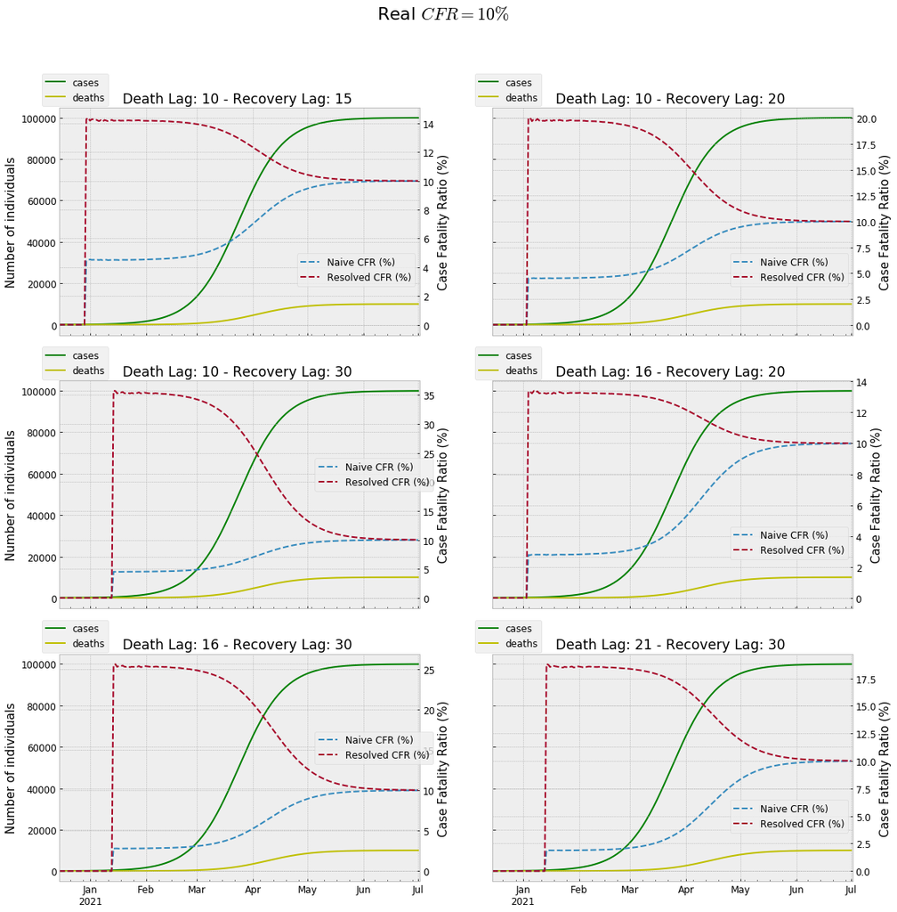

```python
fig, ax = plt.subplots(3,2, sharex=True, sharey=True, figsize = (18,18))
fig.suptitle('Real $CFR  = 10\%$', fontsize = 22)
pivot = 0
for i in range(0,3):
    for k in range(0,2):
        df = sim(time_to_death = combos[pivot][0], time_to_heal = combos[pivot][1])
        ax1 = ax[i,k].twinx()
        df[['Naive CFR (%)', 'Resolved CFR (%)']].plot(linestyle = '--', ax = ax1);
        df[['cases','deaths']].plot(ax = ax[i,k], label = ['Cum. Cases', 'Cum. Deaths'], color = ['g','y']);
        ax[i,k].set_title(f'Death Lag: {combos[pivot][0]} - Recovery Lag: {combos[pivot][1]} ')
        ax[i,k].set_ylabel('Number of individuals', fontsize = 15)
        ax1.set_ylabel('Case Fatality Ratio (%)', fontsize = 15)
        if (i == 1 and k == 0) or (i == 2 and k == 0):
            ax1.legend(bbox_to_anchor=(0.85, 0.33, 0.2, 0.35), fontsize = 12)
        else:
            ax1.legend(bbox_to_anchor=(0.9, 0.03, 0.1, 0.35), fontsize = 12);
        ax[i,k].legend(bbox_to_anchor=(-0.05, 0.97, 0.2, 0.20), fontsize = 12)
        pivot += 1
```

So the crucial final question is:

Which are the average *death lag* and the average *recovery lag* of this epidemic to use in these simulations?

At this point we turn the same question over epidemiologists and virologists, who can surely know better than us the answer.